# Final models traits - forest cover at local and landscape scale

Loading auxiliary function for R2 calculations

```r
source("r2_auxiliary_function.R")
```

Loading data

```r
load("datasets.Rdata")
load("models_outputs/models_combined.Rdata") # saved models results this script
load("models_outputs/models_traits.Rdata") # saved models results separate
load("models_outputs/models_traits_nointeraction.Rdata") # saved models results separate
```

# Combined traits models

```r
mhigh.spe <- glmer(cbind(occor, n.visit-occor) ~
                    forest_site400*lbody_size +
                    forest_site400*nest +
                    forest_site400*diet +
                    forest_site400*lower_stratum +
                    forest_land*lbody_size +
                    forest_land*nest +
                    forest_land*diet +
                    forest_land*lower_stratum +
                    (forest_site400 + forest_land|sp) +
                    (1|landscape:sp) + (1|site:sp) +
                    (lbody_size + nest + diet + lower_stratum|landscape) +
                    (lbody_size + nest + diet + lower_stratum|site),
                    family=binomial, data=high.spe,
                    nAGQ = 1, control = glmerControl(optimizer = "bobyqa",
                                    optCtrl = list(maxfun = 500000)))


mlow.spe <- glmer(cbind(occor, n.visit-occor) ~
                    forest_site400*lbody_size +
                    forest_site400*nest +
                    forest_site400*diet +
                    forest_site400*lower_stratum +
                    forest_land*lbody_size +
                    forest_land*nest +
                    forest_land*diet +
                    forest_land*lower_stratum +
                    (forest_site400 + forest_land|sp) +
                    (1|landscape:sp) + (1|site:sp) +
                    (lbody_size + nest + diet + lower_stratum|landscape) +
                    (lbody_size + nest + diet + lower_stratum|site),
                    family=binomial, data=low.spe,
                    nAGQ = 1, control = glmerControl(optimizer = "bobyqa",
                                    optCtrl = list(maxfun = 500000)))


mhigh.gen <- glmer(cbind(occor, n.visit-occor) ~
                    forest_site400*lbody_size +
                    forest_site400*nest +
                    forest_site400*diet +
                    forest_site400*lower_stratum +
                    forest_land*lbody_size +
                    forest_land*nest +
                    forest_land*diet +
                    forest_land*lower_stratum +
                    (forest_site400 + forest_land|sp) +
                    (1|landscape:sp) + (1|site:sp) +
                    (lbody_size + nest + diet + lower_stratum|landscape) +
                    (lbody_size + nest + diet + lower_stratum|site),
                    family=binomial, data=high.gen,
                    nAGQ = 1, control = glmerControl(optimizer = "bobyqa",
                                    optCtrl = list(maxfun = 500000)))


mlow.gen <- glmer(cbind(occor, n.visit-occor) ~
                    forest_site400*lbody_size +
                    forest_site400*nest +
                    forest_site400*diet +
                    forest_site400*lower_stratum +
                    forest_land*lbody_size +
                    forest_land*nest +
                    forest_land*diet +
                    forest_land*lower_stratum +
                    (forest_site400 + forest_land|sp) +
                    (1|landscape:sp) + (1|site:sp) +
                    (lbody_size + nest + diet + lower_stratum|landscape) +
                    (lbody_size + nest + diet + lower_stratum|site),
                    family=binomial, data=low.gen,
                    nAGQ = 1, control = glmerControl(optimizer = "bobyqa",
                                    optCtrl = list(maxfun = 500000)))
```

# Local and landscape forest cover effects

Estimating effect sizes (slopes) of local and landscape forest cover for each species in each assemblage. Estimates include fixed effects slopes and random slopes of the species.

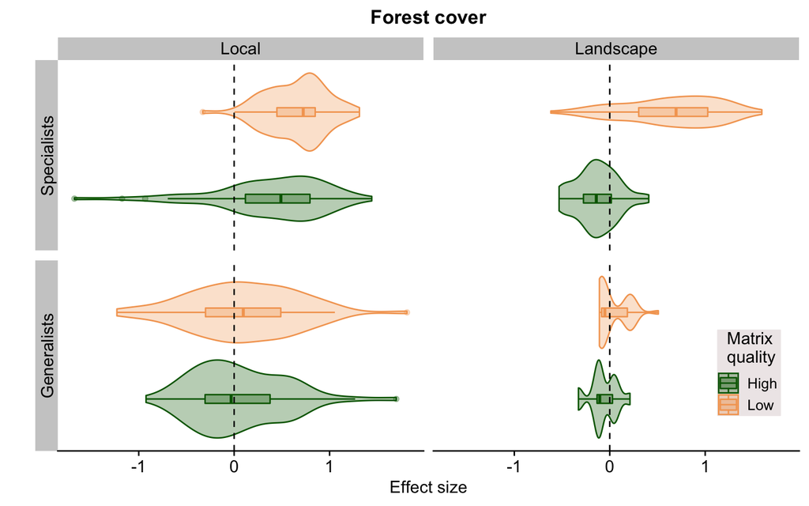

# Trait importance metric

The importance of the trait in explaining habitat loss filtering was calculated using the proportional decrease in the variance of the species random slope of forest cover ($d_{spp[i]$) when you include the trait-environment interaction term ($\beta_{12}$) in the model (Jamil et al. 2013):

$$C_\beta = 1 = \frac{d_{spp[i]}(res)}{d_{spp[i]}(total)}$$

where $d_{spp[i]}(res)$ is the variance of the random slope from model with trait main effects ($\beta_{2}$) and the trait-environment interaction ($\beta_{12}$), and $d_{spp[i]}(total)$ is the same variance term for the model without trait-environment interaction but with the main effects of traits.This proportion explains how much of the effect of habitat loss on each species can be explained by their trait values.

**OBS:** Models without trait*enviroment interaction for the separate traits were previoulsy analyzed in the Rmd scrit `3_modeling_traits_separate.Rmd`.

Models without trait*enviroment interactions for the combined traits:

```r
mhigh.spe2 <- glmer(cbind(occor, n.visit-occor) ~
                    forest_site400 + forest_land +
                    lbody_size +
                    nest +
                    diet +
                    lower_stratum +
                    (forest_site400 + forest_land|sp) +
                    (1|landscape:sp) + (1|site:sp) +
                    (lbody_size + nest + diet + lower_stratum|landscape) +
                    (lbody_size + nest + diet + lower_stratum|site),
                    family=binomial, data=high.spe,
                    nAGQ = 1, control = glmerControl(optimizer = "bobyqa",
                                    optCtrl = list(maxfun = 500000)))


mlow.spe2 <- glmer(cbind(occor, n.visit-occor) ~
                    forest_site400 + forest_land +
                    lbody_size +
                    nest +
                    diet +
                    lower_stratum +
                    (forest_site400 + forest_land|sp) +
                    (1|landscape:sp) + (1|site:sp) +
                    (lbody_size + nest + diet + lower_stratum|landscape) +
                    (lbody_size + nest + diet + lower_stratum|site),
                    family=binomial, data=low.spe,
                    nAGQ = 1, control = glmerControl(optimizer = "bobyqa",
                                    optCtrl = list(maxfun = 500000)))


mhigh.gen2 <- glmer(cbind(occor, n.visit-occor) ~
                    forest_site400 + forest_land +
                    lbody_size +
                    nest +
                    diet +
                    lower_stratum +
                    (forest_site400 + forest_land|sp) +
                    (1|landscape:sp) + (1|site:sp) +
                    (lbody_size + nest + diet + lower_stratum|landscape) +
                    (lbody_size + nest + diet + lower_stratum|site),
                    family=binomial, data=high.gen,
                    nAGQ = 1, control = glmerControl(optimizer = "bobyqa",
                                    optCtrl = list(maxfun = 500000)))


mlow.gen2 <- glmer(cbind(occor, n.visit-occor) ~
                    forest_site400 + forest_land +
                    lbody_size +
                    nest +
                    diet +
                    lower_stratum +
                    (forest_site400 + forest_land|sp) +
                    (1|landscape:sp) + (1|site:sp) +
                    (lbody_size + nest + diet + lower_stratum|landscape) +
                    (lbody_size + nest + diet + lower_stratum|site),
                    family=binomial, data=low.gen,
                    nAGQ = 1, control = glmerControl(optimizer = "bobyqa",
                                    optCtrl = list(maxfun = 500000)))
```

Function to calculate trait importance:

```r
cbeta <- function(m.inter, m.no.inter){
    cbeta <- 1-((VarCorr(m.inter)$sp[2,2] + VarCorr(m.inter)$sp[3,3])
               /(VarCorr(m.no.inter)$sp[2,2] + VarCorr(m.no.inter)$sp[3,3]))
  return(round(100*cbeta))
}
```

```r
comb <- c(cbeta(mhigh.spe, mhigh.spe2),
          cbeta(mlow.spe,  mlow.spe2),
          cbeta(mhigh.gen, mhigh.gen2),
          cbeta(mlow.gen,  mlow.gen2))

bd   <- c(cbeta(bodyhigh.spe, bodyhigh.spe2),
          cbeta(bodylow.spe,  bodylow.spe2),
          cbeta(bodyhigh.gen, bodyhigh.gen2),
          cbeta(bodylow.gen,  bodylow.gen2))

ni   <- c(cbeta(nesthigh.spe, nesthigh.spe2),
          cbeta(nestlow.spe,  nestlow.spe2),
          cbeta(nesthigh.gen, nesthigh.gen2),
          cbeta(nestlow.gen,  nestlow.gen2))

di   <- c(cbeta(diethigh.spe, diethigh.spe2),
          cbeta(dietlow.spe,  dietlow.spe2),
          cbeta(diethigh.gen, diethigh.gen2),
          cbeta(dietlow.gen,  dietlow.gen2))

ls   <- c(cbeta(low_strathigh.spe, low_strathigh.spe2),
          cbeta(low_stratlow.spe,  low_stratlow.spe2),
          cbeta(low_strathigh.gen, low_strathigh.gen2),
          cbeta(low_stratlow.gen,  low_stratlow.gen2))

st   <- c(cbeta(stratumhigh.spe, stratumhigh.spe2),
          cbeta(stratumlow.spe,  stratumlow.spe2),
          cbeta(stratumhigh.gen, stratumhigh.gen2),
          cbeta(stratumlow.gen,  stratumlow.gen2))

fr   <- c(cbeta(frugihigh.spe, frugihigh.spe2),
          cbeta(frugilow.spe,  frugilow.spe2),
          cbeta(frugihigh.gen, frugihigh.gen2),
          cbeta(frugilow.gen,  frugilow.gen2))

is   <- c(cbeta(insehigh.spe, insehigh.spe2),
          cbeta(inselow.spe,  inselow.spe2),
          cbeta(insehigh.gen, insehigh.gen2),
          cbeta(inselow.gen,  inselow.gen2))
```

```r
tra <- data.frame(matrix = c("High quality", "Low quality",
                             "High quality", "Low quality"),
                  habitat = c("Specialists", "Specialists",
                              "Generalists","Generalists"),
                  comb, ni, di, st, is, fr, ls, bd)
colnames(tra)[3:10] <- c("Combined","Nest type", "Main diet",
        "Foraging stratum", "% insectivory", "% frugivory", "% lower strata",
                             "Body mass")
tra
```

```
##         matrix     habitat Combined Nest type Main diet Foraging stratum
## 1 High quality Specialists       17        14         3                4
## 2  Low quality Specialists       22        18         7                0
## 3 High quality Generalists       14        12        15                9
## 4  Low quality Generalists       26        14         9                6
##   % insectivory % frugivory % lower strata Body mass
## 1             2           2              3         1
## 2             3           2              3         5
## 3             9           5              0         0
## 4             1           3              0         1
```

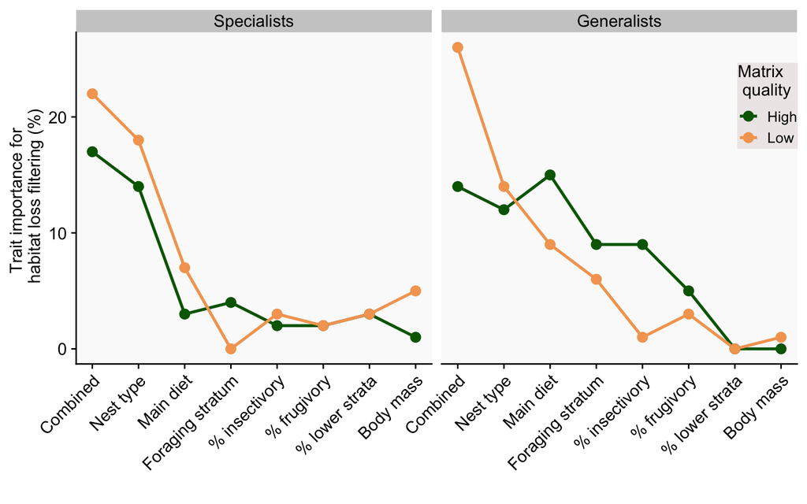

```r
figtrait.env <- tra %>% gather("trait", "value", 3:10) %>%
  mutate(trait = fct_relevel(trait, "Combined","Nest type", "Main diet",
                             "Foraging stratum", "% insectivory", "% frugivory",
                             "% lower strata",
                             "Body mass"),
         habitat = fct_relevel(habitat, "Specialists", "Generalists")) %>%
  arrange(trait) %>%
  mutate(xis=rep(1:8, each=4)) %>%
  ggplot(aes(x=xis, y=value, col=matrix)) + geom_line(size=1) + geom_point(size=3) +
  facet_grid(~habitat) +
  scale_x_continuous(breaks=1:8, labels= c("Combined","Nest type", "Main diet",
                                           "Foraging stratum", "% insectivory", "% frugivory", "% lower strata",
                                           "Body mass")) +
  xlab("") +
  scale_color_manual(name="Matrix \n quality",
                     labels = c("High", "Low"),
                     values = c("darkgreen", "sandybrown")) +
  ylab("Trait importance for \n habitat loss filtering (%)")+
  theme(axis.text.x = element_text(angle=45, hjust=1),
        text = element_text(size=12),
        axis.text = element_text(size=12),
        panel.background = element_rect(fill="#FAFAFA", color="#FAFAFA"),
        legend.box.background = element_rect(fill="snow2", color="snow2"),
        strip.text = element_text(size=12, margin=margin(t=2,b=3)),
        legend.justification = c(1, 0), legend.position = c(1, 0.65))
figtrait.env
```

```r
jpeg("figures/fig_traitXenv.jpg", width=20, height = 12, units="cm", res=150)
figtrait.env
dev.off()
```

# Comparing effect sizes of interaction terms among assemblages

One way to compare the importance of habitat loss filtering across assemblages is to calculate the mean of the absolute values of the effect sizes, given that the effect sizer are all standardized. The mean is important because, there are some assemblages with more than 3 different types of diet, so different number of effects.

```r
all=c(mean(abs(fixef(mhigh.spe)[grep(":", names(fixef(mhigh.spe)))])),
      mean(abs(fixef(mlow.spe) [grep(":", names(fixef(mlow.spe)))])),
      mean(abs(fixef(mhigh.gen)[grep(":", names(fixef(mhigh.gen)))])),
      mean(abs(fixef(mlow.gen) [grep(":", names(fixef(mlow.gen)))])))

local=c(mean(abs(fixef(mhigh.spe)[grep("forest_site400:", names(fixef(mhigh.spe)))])),
        mean(abs(fixef(mlow.spe) [grep("forest_site400:", names(fixef(mlow.spe)))])),
        mean(abs(fixef(mhigh.gen)[grep("forest_site400:", names(fixef(mhigh.gen)))])),
        mean(abs(fixef(mlow.gen) [grep("forest_site400:", names(fixef(mlow.gen)))])))

land=c(mean(abs(fixef(mhigh.spe)[grep(":forest_land", names(fixef(mhigh.spe)))])),
       mean(abs(fixef(mlow.spe)[grep(":forest_land", names(fixef(mlow.spe)))])),
       mean(abs(fixef(mhigh.gen)[grep(":forest_land", names(fixef(mhigh.gen)))])),
       mean(abs(fixef(mlow.gen)[grep(":forest_land", names(fixef(mlow.gen)))])))

data.frame(matrix = c("high", "low", "high", "low"),
           habitat = c("specialist", "specialist", "generalist", "generalist"),
           all = all, local=local, landscape=land) %>%
  kable(digits=3, caption="Effect sizes metric for all, only local, only landscape interaction terms")
```

Effect sizes metric for all, only local, only landscape interaction terms

| matrix | habitat | all | local | landscape |
| --- | --- | --- | --- | --- |
| high | specialist | 0.198 | 0.213 | 0.183 |
| low | specialist | 0.220 | 0.220 | 0.220 |
| high | generalist | 0.213 | 0.268 | 0.158 |
| low | generalist | 0.210 | 0.203 | 0.218 |

# R<sup>2</sup> models

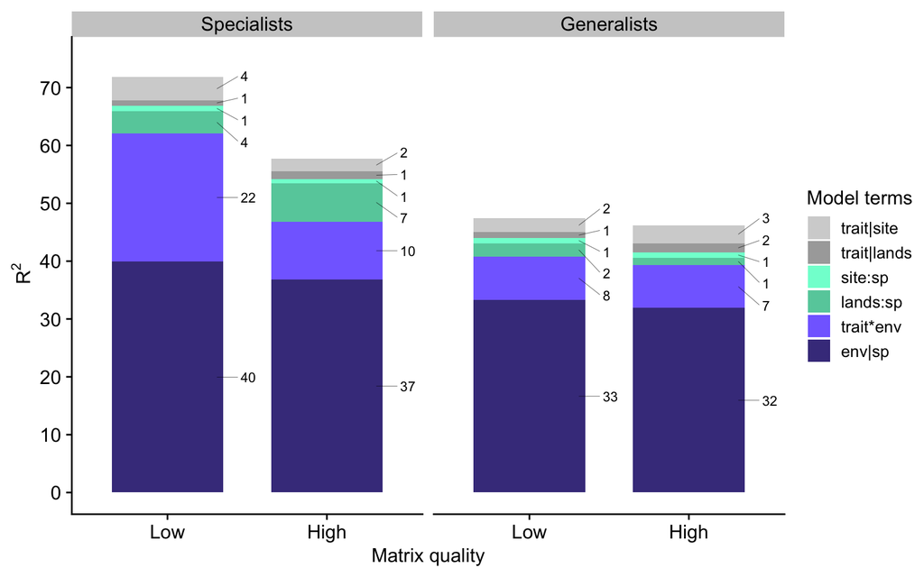

```r
traits = c("lbody_size", "nest", "diet", "lower_stratum")
vals <- bind_rows(list(High_Specialists = r2.calc(mhigh.spe, atrib=traits)*100,
      Low_Specialists=r2.calc(mlow.spe, atrib=traits)*100,
      High_Generalists=r2.calc(mhigh.gen, atrib=traits)*100,
     Low_Generalists=r2.calc(mlow.gen, atrib=traits)*100), .id="assemblage")

colnames(vals) <- c("assemblage", "condicional", "trait*env", "env|sp", "lands:sp", "site:sp", "trait|lands", "trait|site")

vals2 <-  vals %>%
  separate(assemblage, c("matrix", "habitat")) %>%
  select(-condicional) %>%
  pivot_longer(3:8, names_to = "term", values_to = "R2") %>%
  mutate(term = fct_relevel(term,"trait|site", "trait|lands", "site:sp",
                                  "lands:sp", "trait*env","env|sp"),
         habitat = fct_relevel(habitat, "Specialists", "Generalists"),
         matrix = fct_relevel(matrix, "Low", "High")) %>%
  arrange(habitat,matrix,desc(term)) %>%
  group_by(habitat, matrix) %>%
  mutate(yis = cumsum(R2)-R2/2,
         label = as.character(round(R2))) %>% ungroup() %>%
  mutate(xis = rep(rep(c(1.31,2.31), each=6), 2))

fig.part <- ggplot(vals2, aes(x=matrix, y=R2, fill=term)) + geom_col(width=0.7) +
  scale_fill_manual(name="Model terms" ,
                    values = c("lightgrey","darkgrey","aquamarine1",
                               "aquamarine3", "slateblue1", "slateblue4")) +
  facet_wrap(~habitat)+
  scale_y_continuous(name= expression(~ R^2), breaks=seq(0,70,10),
                     limits=c(0,75)) +
  scale_x_discrete(name="Matrix quality") +
  theme(text = element_text(size=12),
        axis.text = element_text(size=12),
        strip.text = element_text(size=12, margin=margin(t=2,b=3))) +
geom_text_repel(data=vals2, aes(label=label, y=yis, x=xis),
                segment.size = 0.15, size=3,
                segment.alpha = 0.7,
                direction="y",
                show.legend=F,   nudge_x = 0.15, hjust=0)

fig.part
```

```r
jpeg("figures/fig_R2.jpg", width=20, height = 12, units="cm", res=150)
fig.part
dev.off()
```

# Trying additive variance partitioning of the fixed effects

```r
# Auxiliary function to calculate R2s of each term in models
r2.calcAD <- function(model, coefs= c("forest_site400", "forest_land"), atrib="diet"){

  coefs = c("(Intercept)", coefs)

  # variance fixed effects
  var.f <- var(as.vector(fixef(model) %*% t(model@pp$X)))

  ############### bein intervention #####

  # variance fixed effects separating main and interation effects
  effects <- names(fixef(model))

  # trait
  efftrait <- effects[!effects %in% grep(":", effects, value=T)]
  efftrait <- efftrait[!efftrait %in% coefs[-1]]
  traitmodel <- model@pp$X[, efftrait]

  traitvec <- fixef(model)[efftrait]
  var.trait <-  var(as.vector(traitvec %*% t(traitmodel)))

  # env
  effenv <- coefs[-1]
  envmodel <- model@pp$X[, effenv]

  envvec <- fixef(model)[effenv]
  var.env <-  var(as.vector(envvec %*% t(envmodel)))

  # interaction
  intermodel <- model@pp$X[, grep(":", colnames(model@pp$X), value=T)]
  intervec <- fixef(model)[colnames(intermodel)]
  var.inter <-  var(as.vector(intervec %*% t(intermodel)))


  #var.trait + var.env + var.inter

  # the variance of the fixed effects withous partition is smaler because
  # in the partitioning I'm ingoring the strong covariance among terms
  # especially because the interaction group of effects is obviously
  # highly correlated with the other terms.


  ############### end intervention #####



  # variance sp random effect (intercept + slope)
  X <- model.matrix(model)
  n <- nrow(X)
  Z <- X[,coefs]
  sigma <- VarCorr(model)$sp

  var.sp <- sum(diag(Z %*% sigma %*% t(Z)))/n


  # variance (trait|site) and (trait|landscape)
  if(length(atrib)>1){
    trait <- c("(Intercept)")
    while(length(atrib)>0){
      cols1 <- grep(atrib[1], colnames(X), value=T)
      cols <- grep(":", cols1, value=T, invert = T)
      trait <- c(trait, cols)
      atrib <- atrib[-1]
    }
  }
  else{
    cols1 <- grep(atrib, colnames(X), value=T)
    cols <- grep(":", cols1, value=T, invert = T)
    trait <- c("(Intercept)", cols)
  }

  W <- X[,trait]
  sigma.site <- VarCorr(model)$site
  var.site <- sum(diag(W %*% sigma.site %*% t(W)))/n
  sigma.land <- VarCorr(model)$landscape
  var.landscape <- sum(diag(W %*% sigma.land %*% t(W)))/n


  # variance (1|landscape:sp) and (1|site:sp)
  var.landscape.sp <- VarCorr(model)$`landscape:sp`[1]
  var.site.sp <- VarCorr(model)$`site:sp`[1]


  denominador <- var.f + var.sp + var.landscape + var.site + var.landscape.sp +
    var.site.sp + pi^2/3

  r2.fix <- var.f/denominador
  r2.cond <- (var.f + var.sp + var.landscape + var.site + var.landscape.sp +
                var.site.sp)/denominador

  res <- data.frame(overall = round(r2.cond,3),
                    fixed.effects = round(r2.fix,3),
                    sp = round(var.sp/denominador, 3),
                    landscape.sp = round(var.landscape.sp/denominador, 3),
                    site.sp = round(var.site.sp/denominador, 3),
                    landscape = round(var.landscape/denominador, 3),
                    site = round(var.site/denominador, 3),
                    var.fix = var.f, ##
                    var.trait = var.trait, # intervention
                    var.env  = var.env,    # intervention
                    var.inter = var.inter)  # intervention
  return(res)
}
```

```r
traits = c("lbody_size", "nest", "diet", "lower_stratum")
vals <- bind_rows(list(High_Specialists = r2.calcAD(mhigh.spe, atrib=traits),
                       Low_Specialists=r2.calcAD(mlow.spe, atrib=traits),
                       High_Generalists=r2.calcAD(mhigh.gen, atrib=traits),
                       Low_Generalists=r2.calcAD(mlow.gen, atrib=traits)), .id="assemblage")

fix.var <- vals[,c(1:3,9:12)]


fix.var$sum = rowSums(fix.var[,5:7])

fix.var$Pvar.trait = fix.var$var.trait*100/fix.var$sum
fix.var$Pvar.env = fix.var$var.env*100/fix.var$sum
fix.var$Pvar.inter = fix.var$var.inter*100/fix.var$sum

kable(fix.var)
```

| assemblage | overall | fixed.effects | var.fix | var.trait | var.env | var.inter | sum | Pvar.trait | Pvar.env | Pvar.inter |
| --- | --- | --- | --- | --- | --- | --- | --- | --- | --- | --- |
| High_Specialists | 0.576 | 0.100 | 0.7743159 | 0.6489231 | 0.4693215 | 0.1744091 | 1.2926538 | 50.20085 | 36.30682 | 13.49233 |
| Low_Specialists | 0.719 | 0.222 | 2.6002822 | 0.7099596 | 4.7385662 | 1.0214285 | 6.4699543 | 10.97318 | 73.23956 | 15.78726 |
| High_Generalists | 0.462 | 0.074 | 0.4507482 | 0.3814725 | 0.1035578 | 0.2167548 | 0.7017851 | 54.35745 | 14.75634 | 30.88621 |
| Low_Generalists | 0.474 | 0.075 | 0.4680544 | 0.4195718 | 0.0831287 | 0.0953402 | 0.5980407 | 70.15774 | 13.90018 | 15.94209 |

# Saving models results

```r
save(mhigh.gen, mhigh.spe, mlow.gen, mlow.spe,
     mhigh.gen2, mhigh.spe2, mlow.gen2, mlow.spe2,
  file="models_outputs/models_combined.Rdata")
```